# Lab7-Remuestreo2: Bootstrap

Estadística No paramétrica

Autor/a

Jorge de la Vega

Fecha de publicación

29 de mayo de 2023

```r
# Paquete con datos de un libro: "Mathematical Statistics with Resampling in R"
library(bootstrap)
```

## Ejemplos de bootstrap

1. **Datos de calidad de riñón:** Se tienen medidas de 157 voluntarios sanos (donadores potenciales) y las variables son:
- `age`: edad del voluntario
- `tot`: medida compuesta global de la función del riñón.

Usualmente la función del riñón declina con la edad, y podemos ajustar un modelo de regresión aproximado.

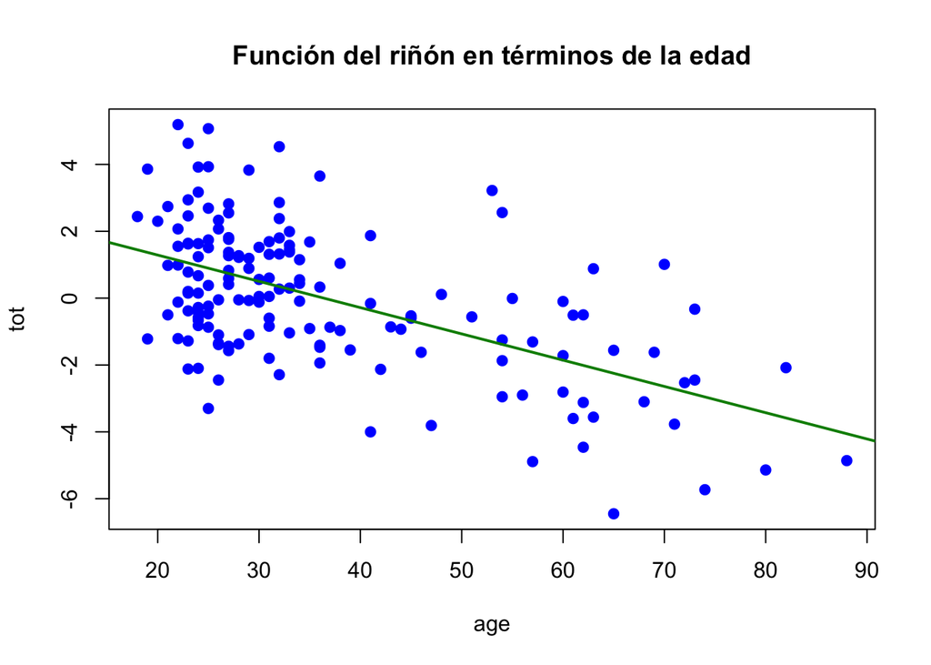

```r
kidney <- read.delim("https://hastie.su.domains/CASI_files/DATA/kidney.txt", header = T, sep ="")
plot(kidney, pch = 19, col ="blue", main = "Función del riñón en términos de la edad")
abline(lm(tot ~ age, data = kidney), col = "green4", lwd =2)
```

Se quiere estimar el coeficiente de correlación entre `age` y `tot`, es la estadística a considerar, y calcular su error estándar. Usando la función jackknife del paquete `bootstrap`:

```r
n <- nrow(kidney)
Tn = function(x, xdata){cor(xdata[x,1],xdata[x,2])}
A <- jackknife(1:n, theta = Tn, kidney)
(A$jack.se) # error estándar
```

```
[1] 0.05822859
```

```r
(A$jack.bias) # sesgo
```

```
[1] 0.002100345
```

La versión de función `bootstrap` es similar, pero la función sólo nos devuelve la muestra bootstrap, a partir de la cual hay que calcular el sesgo y el error estándar de la estadística manualmente:

```r
thetahat <- cor(kidney)[1,2] # estimador observado
B <- bootstrap(1:n, nboot = 500, theta = Tn, kidney)
(se_boot <- sd(B$thetastar)) # error estándar
```

```
[1] 0.05708428
```

```r
(b_boot <- mean(B$thetastar) - thetahat)  # estimación de sesgo
```

```
[1] 0.003253433
```

```r
(theta_boot <- thetahat - b_boot)  # estimador bootstrap corregido por sesgo
```

```
[1] -0.5750921
```

¿Cuándo el sesgo es muy grande? Podemos considerar la regla de dedo: si $|\hat{b_{boot}}/\hat{se}| < 0.25$, entonces el sesgo no es significativo. Pero esta regla se tiene que ajustar a las circunstancias del problema.

```r
abs(b_boot/se_boot) #métrica para evaluar el tamaño del sesgo.
```

```
[1] 0.05699351
```

Entonces esta corrección por sesgo se puede ignorar.

Otro paquete que puede ser de utilidad para realizar bootstrap que da un poco más de información, es el paquete `boot`, que se basa en el libro de Davison & Hinkley: *Bootstrap Methods and Their Application* (Cambridge, 1997).

Para el mismo ejemplo, sólo se requiere especificar la función de manera diferente:, el primer argumento de la función son la muestra original, y el segundo argumento deben ser el que corresponde a los índices a muestrear.

```r
library(boot)
# Estadística de la que se requiere hacer bootstrap:
Tn2 <-  function(datos,ind){cor(datos[ind,1],datos[ind,2])}

# Objeto tipo bootstrap
(Res <- boot(data = kidney,
          statistic = Tn2,
          R = 2000))  # El número de muestras bootstrap a generar.
```

```
ORDINARY NONPARAMETRIC BOOTSTRAP


Call:
boot(data = kidney, statistic = Tn2, R = 2000)


Bootstrap Statistics :
      original      bias    std. error
t1* -0.5718387 0.001710733  0.05754501
```

```r
names(Res) # las muestras bootstrap se guardan en el vector t.
```

```
 [1] "t0"        "t"         "R"         "data"      "seed"      "statistic"
 [7] "sim"       "call"      "stype"     "strata"    "weights"
```

Las réplicas están en la variable `boot1$t`. La notación del paquete `boot` (basado en el libro de Davison y Hinkley), del paquete `bootstrap` (basado en Efron y Tibshirani) y del paquete `resample` (basado en el libro de Laura Chihara y Tim Hesterberg) son diferentes.

2. **Ejemplo de regresión**

Un dispensador médico que libera de manera continua una hormona anti-inflamatoria que se prueba en 27 sujetos. La variable de respuesta $y$ es la cantidad de hormona que permanece en el dispensador cuando se desgasta. Los predictores son

- `lot` = lote de manufactura del dispensador, y
- `hrs` = número de horas de uso del dispositivo antes del desgaste.

Se quiere evaluar el efecto de los factores que afectan a la cantidad de hormona que se que queda en el dispensador. La base de datos hormone es parte del paquete `boostrap`.

```r
library(bootstrap)
head(hormone)
```

```
  Lot hrs amount
1   A  99   25.8
2   A 152   20.5
3   A 293   14.3
4   A 155   23.2
5   A 196   20.6
6   A  53   31.1
```

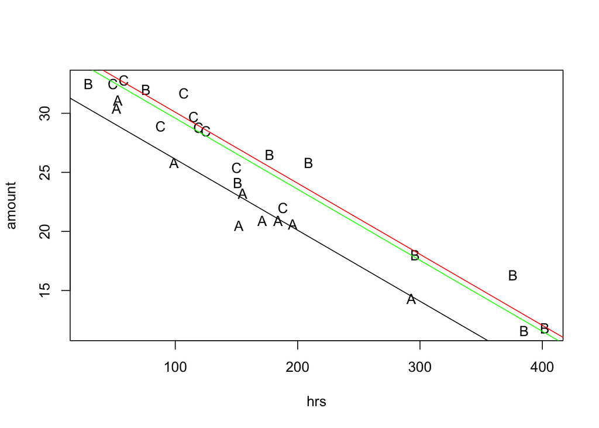

```r
plot(amount ~ hrs, data = hormone, pch = Lot) #Gráfica de los datos
# Ajustamos un modelo lineal a los datos
m1 <- lm(amount ~ hrs + factor(Lot), data=hormone)
# líneas de regresión para cada grupo
abline(a = m1$coefficients[1], b = m1$coefficients[2]) #linea A
abline(a = m1$coefficients[1] + m1$coefficients[3], b = m1$coefficients[2], col = "red") # linea B
abline(a = m1$coefficients[1] + m1$coefficients[4], b = m1$coefficients[2], col = "green") # linea C
```

```r
summary(m1) # Valores ajustados.
```

```
Call:
lm(formula = amount ~ hrs + factor(Lot), data = hormone)

Residuals:
    Min      1Q  Median      3Q     Max
-2.9245 -1.0626 -0.1304  0.8544  2.8061

Coefficients:
              Estimate Std. Error t value Pr(>|t|)
(Intercept)  32.131595   0.748277  42.941  < 2e-16 ***
hrs          -0.060136   0.003474 -17.310 1.10e-14 ***
factor(Lot)B  3.973500   0.809686   4.907 5.87e-05 ***
factor(Lot)C  3.465729   0.769123   4.506 0.000159 ***
---
Signif. codes:  0 '***' 0.001 '**' 0.01 '*' 0.05 '.' 0.1 ' ' 1

Residual standard error: 1.605 on 23 degrees of freedom
Multiple R-squared:  0.945, Adjusted R-squared:  0.9378
F-statistic: 131.8 on 3 and 23 DF,  p-value: 1.254e-14
```

En principio, se esperaría que el lote no afectara a $y$. Y se esperaría que a mayor uso, la cantidad residual fuera menor.

En este problema de regresión, se pueden aplicar el bootstrap de diferentes maneras:

- *Muestreo sobre las observaciones de los datos*. Este sería el esquema más tradicional.
- *Muestreo sobre residuales*. Se hace bootstrap sobre los residuales, y con ellos se calculan las muestras bootstrap de las respuestas. En este caso, se dejan fijos los valores de los predictores, y sólo se cambia el valor de la respuesta. Esto funciona en el contexto donde se considere a los predictores como no aleatorios.

**Bootstrap sobre las observaciones**

Creamos la función que toma los coeficientes de la muestra generada

```r
Tn <- function(datos,ind){
       lm(amount ~ hrs + factor(Lot), data = datos[ind,])$coefficients
}
(z2 <- boot(data = hormone, statistic = Tn, R=1000))
```

```
ORDINARY NONPARAMETRIC BOOTSTRAP


Call:
boot(data = hormone, statistic = Tn, R = 1000)


Bootstrap Statistics :
       original        bias    std. error
t1* 32.13159495  0.0575354964  0.80820976
t2* -0.06013605 -0.0003997148  0.00401111
t3*  3.97349967  0.0959407065  0.87946711
t4*  3.46572938 -0.0370573156  0.69901951
```

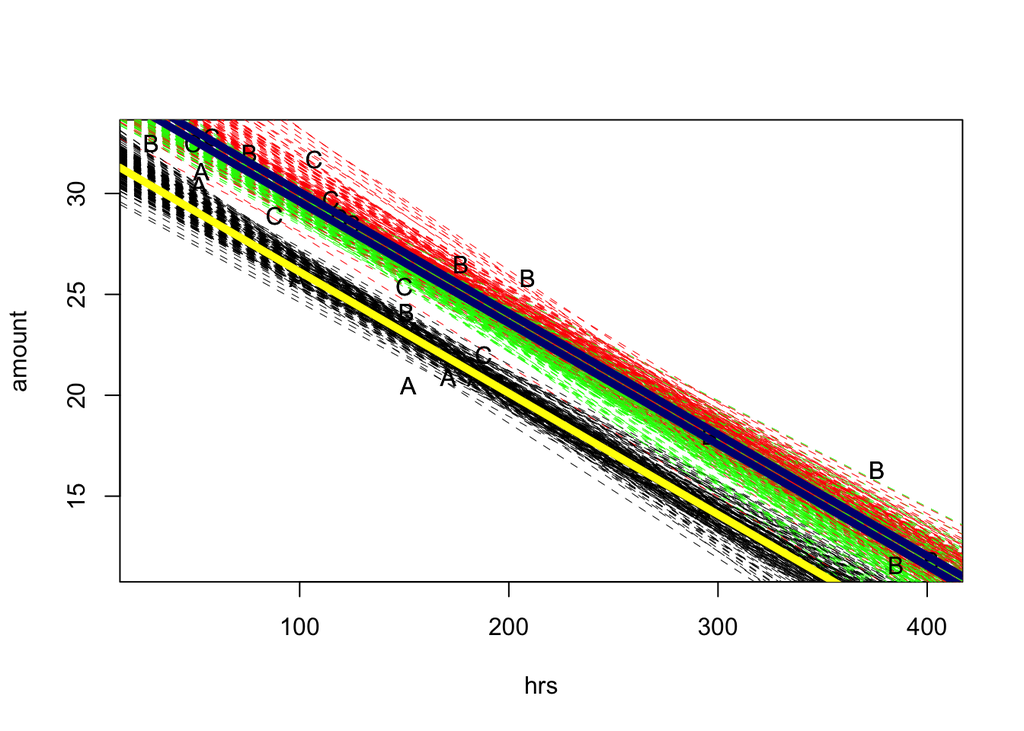

```r
plot(amount ~ hrs, data = hormone, pch = Lot) #Gráfica de los datos

for(i in 1:200){
  abline(a = z2$t[i,1],
         b = z2$t[i,2], lwd = 0.5, lty = 2) # A
  abline(a = z2$t[i,1] + z2$t[i,3] ,
         b = z2$t[i,2], col = "red", lwd = 0.5, lty = 2) # B
  abline(a = z2$t[i,1] + z2$t[i,4] ,
         b = z2$t[i,2], col = "green", lwd = 0.5, lty = 2) # C
}

points(hormone$hrs, hormone$amount, pch = hormone$Lot)
abline(a = m1$coefficients[1], b = m1$coefficients[2], col = "yellow", lwd = 5) # A
abline(a = m1$coefficients[1] + m1$coefficients[3], b = m1$coefficients[2], col="navy", lwd=5) # B
abline(a = m1$coefficients[1] + m1$coefficients[4], b = m1$coefficients[2], col="navy", lwd=5) # C
```

**Bootstrap sobre los residuales**

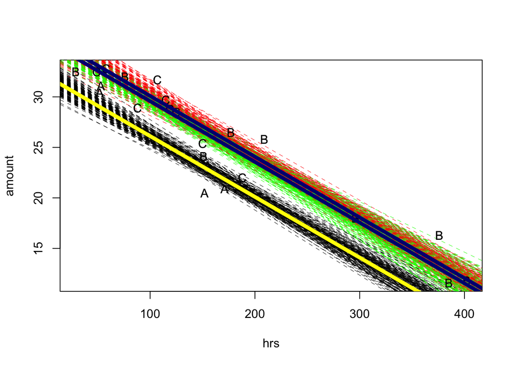

```r
m1 <- lm(amount ~ hrs + factor(Lot), data=hormone)
beta <- m1$coefficients # coeficientes se consideran fijos.
X <- model.matrix(m1)   # predictores son fijos. Esta es la matriz del modelo de regresión

regres <- function(residuos, ind, X, beta){
  # Esta función sólo hace bootstrap sobre los residuales
  y <- X %*% beta + residuos[ind]
  return(lm(y ~ X - 1)$coefficients) # se quita la constante porque ya está incluida en X.
}
z2 <- boot(data = m1$residuals,
          statistic = regres,
          X = model.matrix(m1),  # La matriz se pasa fija a la función que hace el bootstrap
          beta = m1$coefficients,
          R = 1000)

plot(amount ~ hrs, data = hormone, pch = Lot) #Gráfica de los datos

for(i in 1:200){
  abline(a = z2$t[i,1],
         b = z2$t[i,2], lwd = 0.5, lty = 2) # A
  abline(a = z2$t[i,1] + z2$t[i,3] ,
         b = z2$t[i,2], col = "red", lwd = 0.5, lty = 2) # B
  abline(a = z2$t[i,1] + z2$t[i,4] ,
         b = z2$t[i,2], col = "green", lwd = 0.5, lty = 2) # C
}

points(hormone$hrs, hormone$amount, pch = hormone$Lot)
abline(a = m1$coefficients[1], b = m1$coefficients[2], col = "yellow", lwd = 5) # A
abline(a = m1$coefficients[1] + m1$coefficients[3], b = m1$coefficients[2], col="navy", lwd=5) # B
abline(a = m1$coefficients[1] + m1$coefficients[4], b = m1$coefficients[2], col="navy", lwd=5) # C
```

3. **Precios de propiedades en Seattle**. Los datos siguientes corresponden a una muestra de precios de venta de propiedades en Seattle en 2002. Los datos no distinguen entre propiedades residenciales que son la mayoría, pero hay algunas comerciales en la muestra, lo cual puede incrementar el precio promedio de venta muestral. Una estadística más resistente a valores extremos es la media recortada.

```r
precios <- c(142, 175, 197.5, 149.4, 705, 232, 50, 146.5, 155, 1850, 132.5, 215, 116.7, 244.9, 290, 200, 260, 449.9, 66.407, 164.95, 362, 307, 266, 166, 375, 244.95, 210.95, 265, 296, 335, 335, 1370, 256, 148.5, 987.5, 324.5, 215.5, 684.5, 270, 330, 222, 179.8, 257, 252.95, 149.95, 225, 217, 570, 507, 190)
mean(precios)
```

```
[1] 329.2571
```

```r
mean(precios, trim = 0.25)
```

```
[1] 244.0019
```

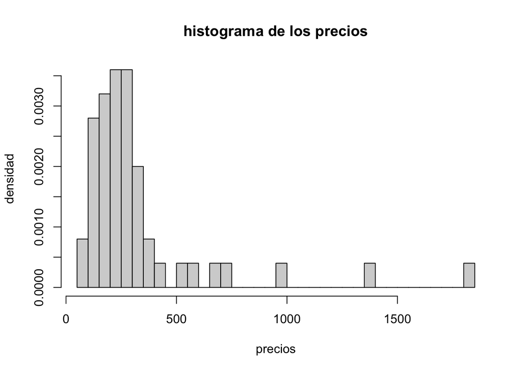

```r
hist(precios, probability = T, main = "histograma de los precios", ylab = "densidad", breaks = 30)
```

¿Cuál es la distribución muestral de $x_{25\%}$? Podemos estimar lo que necesitamos con bootstrap.

```r
media.recortada <- function(x,ind){mean(x[ind], trim = 0.25)}
(boot1 <- boot(data = precios, statistic = media.recortada, R = 2000))
```

```
ORDINARY NONPARAMETRIC BOOTSTRAP


Call:
boot(data = precios, statistic = media.recortada, R = 2000)


Bootstrap Statistics :
    original    bias    std. error
t1* 244.0019 0.8395173    17.87734
```

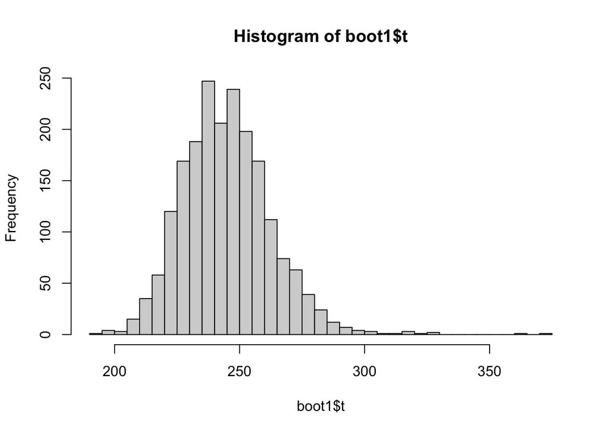

```r
hist(boot1$t, breaks = 50)
```

### Intervalos de confianza bootstrap

Hay diferentes maneras de calcular intervalos de confianza. Varian en su facilidad de cómputo, supuestos y exactitud. Todos se basan en el error estándar bootstrap $\hat{se}_{boot}= \sqrt{v_{boot}}$. Los métodos son:

- bootstrap-normal estándar
- bootstrap-básico
- bootstrap-percentil
- bootstrap-BCa
- bootstrap-t

```r
(a1 <- boot.ci(boot1, conf = c(0.90,0.95), type = c("norm", "basic", "perc", "bca")))
```

```
BOOTSTRAP CONFIDENCE INTERVAL CALCULATIONS
Based on 2000 bootstrap replicates

CALL :
boot.ci(boot.out = boot1, conf = c(0.9, 0.95), type = c("norm",
    "basic", "perc", "bca"))

Intervals :
Level      Normal              Basic
90%   (213.8, 272.6 )   (213.2, 269.5 )
95%   (208.1, 278.2 )   (206.3, 274.3 )

Level     Percentile            BCa
90%   (218.5, 274.8 )   (219.1, 276.3 )
95%   (213.7, 281.7 )   (214.4, 282.6 )
Calculations and Intervals on Original Scale
```

Para el bootstrap-t se requiere obtener el error estándar estimado en cada cálculo bootstrap.

```r
media.recortada2 <- function(x,ind){
                     thetahat.star <- mean(x[ind], trim = 0.25)
                     var.star <- sum((x[ind]-thetahat.star)^2)/(length(x[ind]))^2
                     return(c(thetahat.star,var.star))}
(boot2 <- boot(data = precios, statistic = media.recortada2, R = 2000))
```

```
ORDINARY NONPARAMETRIC BOOTSTRAP


Call:
boot(data = precios, statistic = media.recortada2, R = 2000)


Bootstrap Statistics :
     original      bias    std. error
t1*  244.0019   0.7722817    17.40087
t2* 2112.8421 -27.5802177  1106.86489
```

```r
(a2 <- boot.ci(boot2, conf = c(0.90,0.95), type = "stud"))
```

```
BOOTSTRAP CONFIDENCE INTERVAL CALCULATIONS
Based on 2000 bootstrap replicates

CALL :
boot.ci(boot.out = boot2, conf = c(0.9, 0.95), type = "stud")

Intervals :
Level    Studentized
90%   (214.4, 278.0 )
95%   (207.3, 289.1 )
Calculations and Intervals on Original Scale
```

Podemos armar una gráfica comparativa. La línea vertical es el valor del parámetro estimado. Noten que no todos los intervalos son simétricos alrededor del estimado.

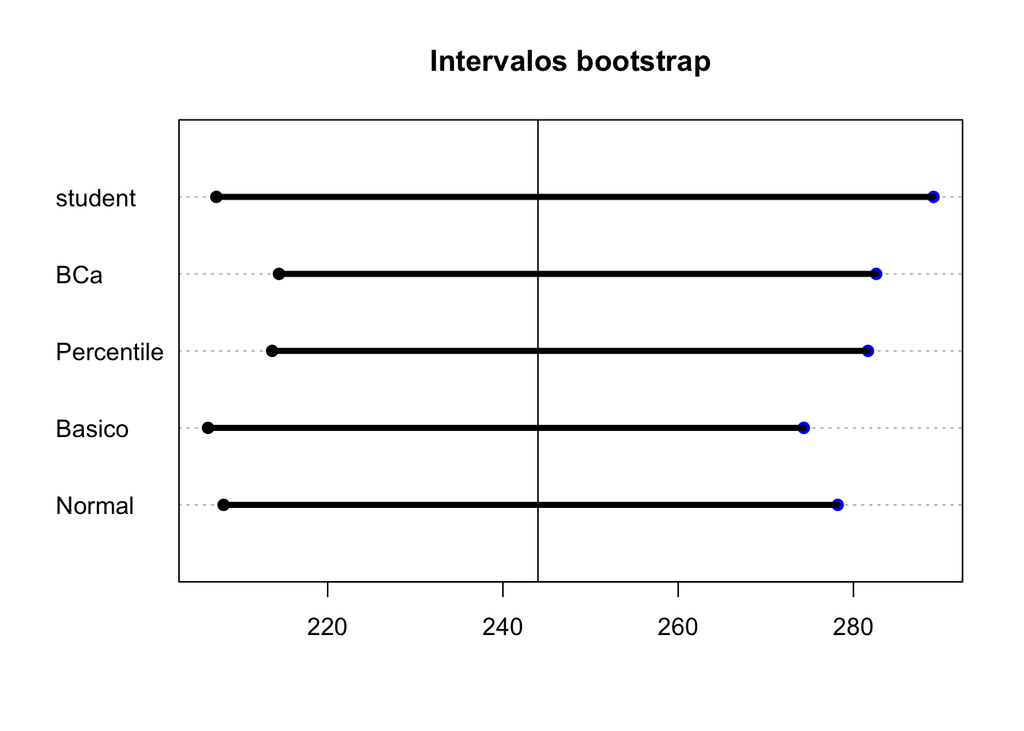

```r
tabla <- data.frame(intervalo = c("Normal", "Basico","Percentile", "BCa", "student"),
                    lim.inf = c(a1$normal[2,2], a1$basic[2,4], a1$percent[2,4],
                                a1$bca[2,4], a2$student[2,4]),
                    lim.sup = c(a1$normal[2,3], a1$basic[2,5], a1$percent[2,5],
                                a1$bca[2,5], a2$student[2,5]))
 dotchart(tabla$lim.inf,labels = tabla$intervalo,xlim=range(tabla$lim.inf,tabla$lim.sup),
          pch = 19, main = "Intervalos bootstrap")
 points(tabla$lim.sup,1:nrow(tabla), col = "blue", pch = 19)
 abline(v= mean(precios, trim = 0.25))
 for(i in 1:5) segments(tabla$lim.inf[i],i,tabla$lim.sup[i],i, lwd = 4)
```

## Problema 6

Generar 100 muestras X1,…,X20 de una población normal N (θ,1) con θ = 1

```r
# checar

#simNormal <- NULL
#for(i in c(1:100)){
#       simNormal[,i] <- rnorm(20, mean=1, sd=1)}
```

•a) Para cada muestra calcular los estimados bootstrap y jackknife de varianza paea ˆθ = ̄X y calcular la media y desviación estándar de estos estimadores de varianza sobre las 100 muestras.

•b) Repetir (a) para la estadística ̄X2 y comparar resultados. Den una explicación de lo que encontraron.